# Flights Data Exploration

## by Ahunanya Obinna

# Effect of Delays on Carriers

## Dataset Overview

The dataset consists of information regarding 1651 flight data, including carrier names, airport names, year, month, and other delay information. Twenty-nine data points were removed from the dataset due to missing information

#### Investigation Overview

The dataset has been loaded into a dataframe revealing 1651 flight schedules with 22 variables, I am particularly interested in delays affecting carriers. The main features of interest to me in this dataset are month, carrier_name, arr_delay, carrier_delay, weather_delay, nas_delay, security_delay and late_aircraft_delay.

# Distribution of Carriers

The distribution of carrier are distinctively varied in counts, with Skywest Airlines Inc having the largest frequency with 244 counts.

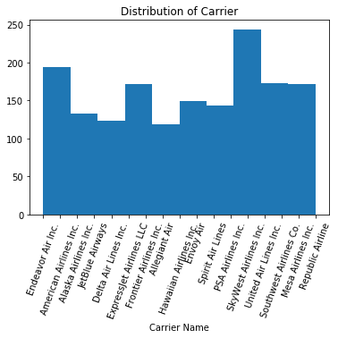

```python
#distribution of carrier names

plt.hist(data = flights, x = 'carrier_name')
plt.title('Distribution of Carrier')
plt.xlabel('Carrier Name')
plt.xticks(rotation = 70);
```

# Distribution of Delays

All 6 delays variables have predominantly low values with high frequency, and high values with much lower frequency causing a right skewed distribution across all variables.

For a clearer view on the distribution of the arrival delay variable, a logarithmic graph was ploted which confirmed low values with high frequency gradually tailing off smoothly slightly above 1000.

Carrier delay show high value outliers admist high frequecy lower values which skewed the distribution to the right.

Remaining 4 delay variables(weather, security, late aircraft and nas) show similar trend.

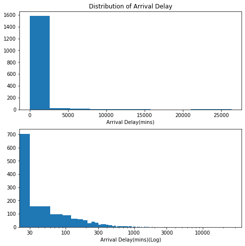

```python
#Distribution of arrival delay
plt.figure(figsize = [8, 8])
plt.subplot(2, 1, 1)
plt.hist(data = flights, x = 'arr_delay')
plt.title('Distribution of Arrival Delay')
plt.xlabel('Arrival Delay(mins)')

plt.subplot(2, 1, 2)
bins = np.arange(0, flights['arr_delay'].max()+30,30)
plt.hist(data = flights, x = 'arr_delay', bins = bins)
plt.xscale('log')
plt.xlabel('Arrival Delay(mins)(Log)')
plt.xticks([30, 100, 300, 1000, 3000, 10000], [30, 100, 300, 1000, 3000, 10000]);
```

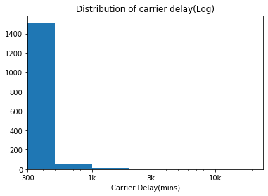

```python
#Distribution of carrier delay
bins = np.arange(0, flights['carrier_delay'].max()+500,500)
plt.hist(data = flights, x = 'carrier_delay', bins = bins)
plt.title('Distribution of carrier delay(Log)')
plt.xlabel('Carrier Delay(mins)')
plt.xscale('log')
plt.xticks([300, 1000, 3000, 10000], [300, '1k', '3k', '10k']);
```

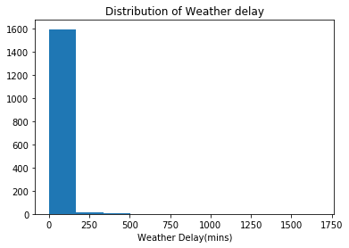

```python
plt.hist(data = flights, x = 'weather_delay')
plt.title('Distribution of Weather delay')
plt.xlabel('Weather Delay(mins)');
```

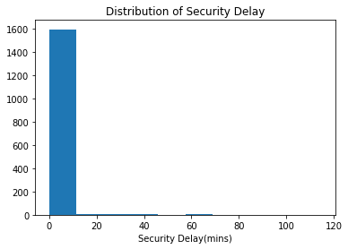

```python
plt.hist(data = flights, x = 'security_delay')
plt.title('Distribution of Security Delay')
plt.xlabel('Security Delay(mins)');
```

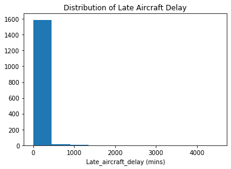

```python
plt.hist(data = flights, x = 'late_aircraft_delay')
plt.title('Distribution of Late Aircraft Delay')
plt.xlabel('Late_aircraft_delay (mins)');
```

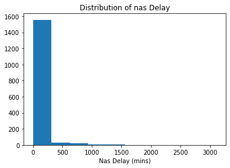

```python
plt.hist(data = flights, x = 'nas_delay')
plt.title('Distribution of nas Delay')
plt.xlabel('Nas Delay (mins)');
```

# Correlation Between Variables

Heatmap shows very strong correlation between 'arrival' and 'carrier' delay variables with a coeficient of 0.977, a strong correlation between 'arrival' and 'late aircraft' delay with a coeficient of 0.857, and a fairly strong correlation between 'nas' and 'arrival' delays, 'carrier' and 'late aircraft' delay, and 'weather' versus 'arrival' delay.

These strongly correlated variables would be investigated further to get a closer look at their relationships.

'arr_flights' does not seem to show very strong correlation with other variables aside a fairly strong correlation with arrival delay and carrier delay

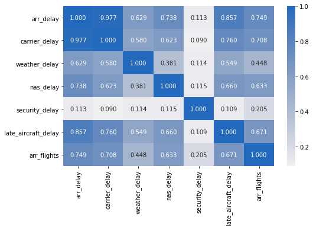

```python
plt.figure(figsize = [8, 5])
sb.heatmap(flights[num_vars].corr(), annot = True, fmt = '.3f',
           cmap = 'vlag_r', center = 0);
```

## Exploring correlation between delay variables

The use of transperancy was implored in the scatter plot to show a clearer picture initially hampered by over plotting of variables, the result is an affirmation of what was already revealed by the matrix plotted previously.

Arrival delay and carrier delay show very strong correlation, likewise arrival delay and late_aircraft_delay, there is a fairly strong correlation between nas delay and arrival delay, as well as carrier delay and late_aircraft_delay, weather delay and arrival delay show a fairly strong correlation.

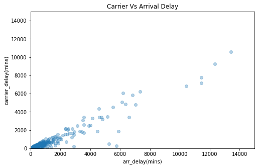

```python
plot_scatter(flights, 'arr_delay', 'carrier_delay')
plt.xlim(0,15000)
plt.ylim(0,15000)
plt.title('Carrier Vs Arrival Delay');
```

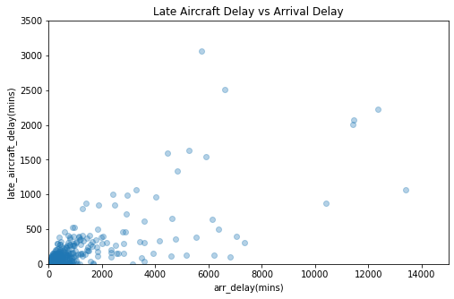

```python
plot_scatter(flights, 'arr_delay', 'late_aircraft_delay')
plt.xlim(0, 15000)
plt.ylim(0, 3500)
plt.title('Late Aircraft Delay vs Arrival Delay');
```

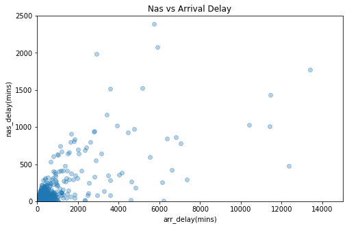

```python
plot_scatter(flights,'arr_delay', 'nas_delay')
plt.xlim(0, 15000)
plt.ylim(0, 2500)
plt.title('Nas vs Arrival Delay');
```

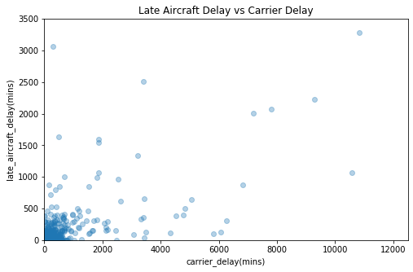

```python
plot_scatter(flights, 'carrier_delay', 'late_aircraft_delay')
plt.xlim(0, 12500)
plt.ylim(0, 3500)
plt.title('Late Aircraft Delay vs Carrier Delay');
```

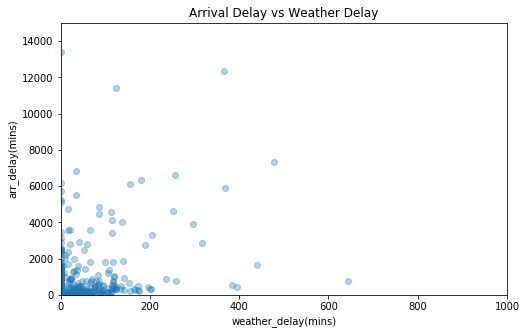

```python
plot_scatter(flights, 'weather_delay', 'arr_delay')
plt.xlim(0, 1000)
plt.ylim(0, 15000)
plt.title('Arrival Delay vs Weather Delay');
```

## Average Delay by Carriers

From the average barplot, it is clear that 'arrival delay' has the highest impact on carriers with an average sum of 5272 mins of delay across carriers, next to 'carrier delay' accounting for an average of of 3334 mins of delay, followed by 'late_aircraft_delay'(873 mins), next to nas_delay(847 mins), 'weather_delay' and 'security_delay' with the least impact accounting for 204mins and 12mins of average sum respectively.

Carriers that show up as top 3 across all 6 delay variables are 'American Airlines Inc.' with a count of 6, 'PSA Airlines Inc' with a count of 3, 'Southwest Airlines Inc.' with a count of 3, 'Delta Air Lines Inc.' with a count of 3, 'SkyWest Airlines Inc.' with a count of 2, 'Spirit Air Lines' with a count of 1.

This shows that the carrier that suffers the most delay is the American Airlines Inc, with PSA, Southwest and Delta Airlines following right after.

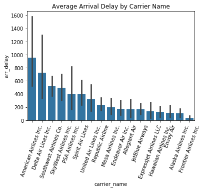

```python
plot_barplot(flights, 'carrier_name', 'arr_delay', arr_order)
plt.title('Average Arrival Delay by Carrier Name');
```

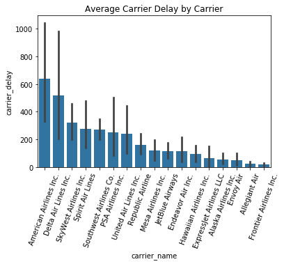

```python
plot_barplot(flights, 'carrier_name', 'carrier_delay', carrier_order)
plt.title('Average Carrier Delay by Carrier');
```

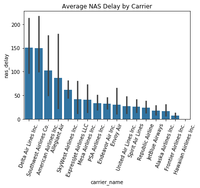

```python
plot_barplot(flights, 'carrier_name', 'nas_delay', nas_order)
plt.title('Average NAS Delay by Carrier');
```

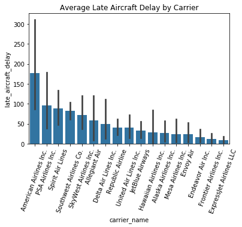

```python
plot_barplot(flights, 'carrier_name', 'late_aircraft_delay', late_order)
plt.title('Average Late Aircraft Delay by Carrier');
```

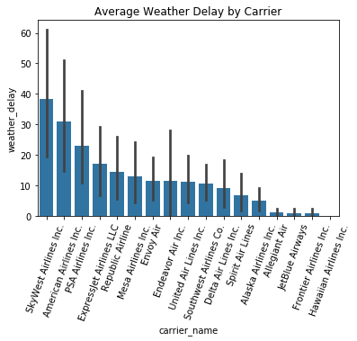

```python
plot_barplot(flights, 'carrier_name', 'weather_delay', weather_order)
plt.title('Average Weather Delay by Carrier');
```

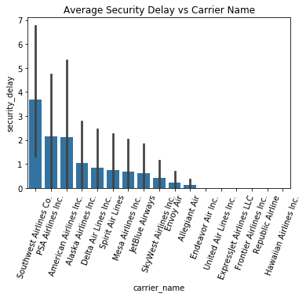

```python
plot_barplot(flights, 'carrier_name', 'security_delay', security_order)
plt.title('Average Security Delay vs Carrier Name');
```

# Color and Shape encoding for Carriers Affected the Worse by Delays

Plotting a graph using color and shape encoding for four carrier_names (American Airlines Inc., Skywest Airline Inc, Delta Airline Inc., Southwest Airlines Inc.) affected the worse by delays, showed how various combinations of delays impacted on these carriers.

It is quite surprising weather_delay did not have a very strong impact on carrier as I expected.

I have therefor concluded from the plot that arrival delay and carrier delay have the strongest impact on carriers, clearly revealed by the interraction from the color scatter plot.

American Airlines Inc., suffering the higehest delay largely due to arrival and carrier delays.

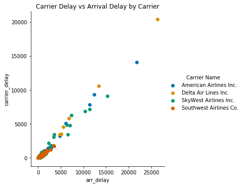

```python
plot_color_graph(carrier_4, 'arr_delay', 'carrier_delay', 'carrier_name')
plt.title('Carrier Delay vs Arrival Delay by Carrier');
```

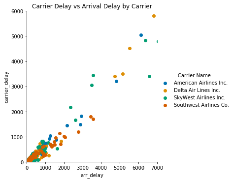

```python
plot_color_graph(carrier_4, 'arr_delay', 'carrier_delay', 'carrier_name')
plt.xlim(0, 7000)
plt.ylim(0, 6000)
plt.title('Carrier Delay vs Arrival Delay by Carrier');
```

Zooming in on the clusterred plots to gain clearer insights on plot interraction re affirms delays have a very strong impact on carriers.

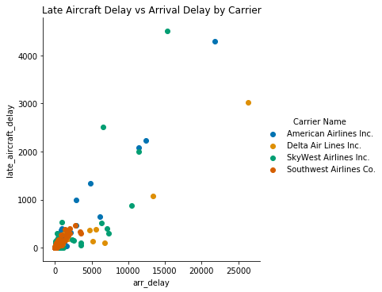

```python
plot_color_graph(carrier_4, 'arr_delay', 'late_aircraft_delay', 'carrier_name')
plt.title('Late Aircraft Delay vs Arrival Delay by Carrier');
```

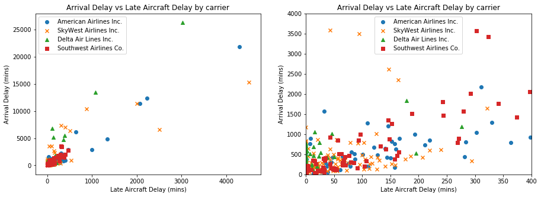

```python
plt.figure(figsize = [15, 5])

plt.subplot(1, 2, 1)
cat_markers = [['American Airlines Inc.', 'o'],
               ['SkyWest Airlines Inc.', 'x'],
              ['Delta Air Lines Inc.', '^' ],
              ['Southwest Airlines Co.', 's']]

for cat, marker in cat_markers:
    df_cat = flights[flights['carrier_name'] == cat]
    plt.scatter(data = df_cat, x = 'late_aircraft_delay', y = 'arr_delay', marker = marker)
    plt.xlabel('Late Aircraft Delay (mins)')
    plt.ylabel('Arrival Delay (mins)')
    plt.title('Arrival Delay vs Late Aircraft Delay by carrier')

plt.legend(['American Airlines Inc.', 'SkyWest Airlines Inc.', 'Delta Air Lines Inc.', 'Southwest Airlines Co.'])

plt.subplot(1, 2, 2)
cat_markers = [['American Airlines Inc.', 'o'],
               ['SkyWest Airlines Inc.', 'x'],
              ['Delta Air Lines Inc.', '^' ],
              ['Southwest Airlines Co.', 's']]

for cat, marker in cat_markers:
    df_cat = flights[flights['carrier_name'] == cat]
    plt.scatter(data = df_cat, x = 'late_aircraft_delay', y = 'arr_delay', marker = marker)
    plt.xlim(0, 400)
    plt.ylim(0, 4000)
    plt.xlabel('Late Aircraft Delay (mins)')
    plt.ylabel('Arrival Delay (mins)')
    plt.title('Arrival Delay vs Late Aircraft Delay by carrier')

plt.legend(['American Airlines Inc.', 'SkyWest Airlines Inc.', 'Delta Air Lines Inc.', 'Southwest Airlines Co.']);
```

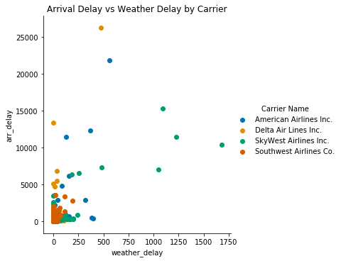

```python
plot_color_graph(carrier_4, 'weather_delay', 'arr_delay', 'carrier_name')
plt.title('Arrival Delay vs Weather Delay by Carrier');
```